# IA Assignment 5 RNN-LSTM

**Import Required Libraries**

```python
import numpy as np
import pandas as pd
import matplotlib.pyplot as plt
import seaborn as sns
from sklearn import preprocessing, model_selection, metrics
```

**Upload Dataset**

```python
dataset = pd.read_csv("C:/Users/Theju/Desktop/Intelligent Analytics/Assignment/RNN/Appliances_Energy_Prediction_Dataset.csv")
```

```python
dataset.head()
```

|  | date | Appliances | lights | T1 | RH_1 | T2 | RH_2 | T3 | RH_3 | T4 | ... | T9 | RH_9 | T_out | Press_mm_hg | RH_out | Windspeed | Visibility | Tdewpoint | rv1 | rv2 |
| --- | --- | --- | --- | --- | --- | --- | --- | --- | --- | --- | --- | --- | --- | --- | --- | --- | --- | --- | --- | --- | --- |
| 0 | 2016-01-11 17:00:00 | 60 | 30 | 19.89 | 47.596667 | 19.2 | 44.790000 | 19.79 | 44.730000 | 19.000000 | ... | 17.033333 | 45.53 | 6.600000 | 733.5 | 92.0 | 7.000000 | 63.000000 | 5.3 | 13.275433 | 13.275433 |
| 1 | 2016-01-11 17:10:00 | 60 | 30 | 19.89 | 46.693333 | 19.2 | 44.722500 | 19.79 | 44.790000 | 19.000000 | ... | 17.066667 | 45.56 | 6.483333 | 733.6 | 92.0 | 6.666667 | 59.166667 | 5.2 | 18.606195 | 18.606195 |
| 2 | 2016-01-11 17:20:00 | 50 | 30 | 19.89 | 46.300000 | 19.2 | 44.626667 | 19.79 | 44.933333 | 18.926667 | ... | 17.000000 | 45.50 | 6.366667 | 733.7 | 92.0 | 6.333333 | 55.333333 | 5.1 | 28.642668 | 28.642668 |
| 3 | 2016-01-11 17:30:00 | 50 | 40 | 19.89 | 46.066667 | 19.2 | 44.590000 | 19.79 | 45.000000 | 18.890000 | ... | 17.000000 | 45.40 | 6.250000 | 733.8 | 92.0 | 6.000000 | 51.500000 | 5.0 | 45.410389 | 45.410389 |
| 4 | 2016-01-11 17:40:00 | 60 | 40 | 19.89 | 46.333333 | 19.2 | 44.530000 | 19.79 | 45.000000 | 18.890000 | ... | 17.000000 | 45.40 | 6.133333 | 733.9 | 92.0 | 5.666667 | 47.666667 | 4.9 | 10.084097 | 10.084097 |

5 rows × 29 columns

```python
print('The number of rows in dataset is - ' , dataset.shape[0])
print('The number of columns in dataset is - ' , dataset.shape[1])
```

```
The number of rows in dataset is -  19735
The number of columns in dataset is -  29
```

```python
#Number of null values in all columns
dataset.isnull().sum().sort_values(ascending = True)
```

```
date           0
Tdewpoint      0
Visibility     0
Windspeed      0
RH_out         0
Press_mm_hg    0
T_out          0
RH_9           0
T9             0
RH_8           0
T8             0
RH_7           0
T7             0
rv1            0
RH_6           0
RH_5           0
T5             0
RH_4           0
T4             0
RH_3           0
T3             0
RH_2           0
T2             0
RH_1           0
T1             0
lights         0
Appliances     0
T6             0
rv2            0
dtype: int64
```

**Explotratory Data Analysis**

```python
#Divide the columns based on type for clear column management

col_time=["date"]

col_temp = ["T1","T2","T3","T4","T5","T6","T7","T8","T9"]

col_hum = ["RH_1","RH_2","RH_3","RH_4","RH_5","RH_6","RH_7","RH_8","RH_9"]

col_weather = ["T_out", "Tdewpoint","RH_out","Press_mm_hg",
                "Windspeed","Visibility"]
col_light = ["lights"]

col_randoms = ["rv1", "rv2"]

col_target = ["Appliances"]
```

```python
# Seperate dependent and independent variables
feature_vars = train[ col_time + col_temp + col_hum + col_weather + col_light + col_randoms ]
target_vars = train[col_target]
```

```python
# Check the distribution of values in lights column
feature_vars.lights.value_counts()
```

```
0     11423
10     1650
20     1240
30      424
40       57
50        5
70        1
60        1
Name: lights, dtype: int64
```

```python
# Due to lot of zero enteries this column is of not much use and will be ignored in rest of the model
_ = feature_vars.drop(['lights'], axis=1 , inplace= True) ;
```

```python
target_vars.describe()
```

|  | Appliances |
| --- | --- |
| count | 14801.000000 |
| mean | 97.710290 |
| std | 102.595342 |
| min | 10.000000 |
| 25% | 50.000000 |
| 50% | 60.000000 |
| 75% | 100.000000 |
| max | 1070.000000 |

Observations

Temperature columns - Temperature inside the house varies between 14.89 Deg & 29.85 Deg , temperatire outside (T6) varies between -6.06 Deg to 28.29 Deg . The reason for this variation is sensors are kept outside the house

Humidiy columns - Humidity inside house varies is between 20.60% to 63.36% with exception of RH_5 (Bathroom) and RH_6 (Outside house) which varies between 29.82% to 96.32% and 1% to 99.9% respectively.

```python
feature_vars.head(2)
```

|  | date | T1 | T2 | T3 | T4 | T5 | T6 | T7 | T8 | T9 | ... | RH_8 | RH_9 | T_out | Tdewpoint | RH_out | Press_mm_hg | Windspeed | Visibility | rv1 | rv2 |
| --- | --- | --- | --- | --- | --- | --- | --- | --- | --- | --- | --- | --- | --- | --- | --- | --- | --- | --- | --- | --- | --- |
| 9544 | 2016-03-17 23:40:00 | 22.6 | 19.5 | 21.50 | 22.89 | 19.166667 | 2.863333 | 21.0 | 22.89 | 19.89 | ... | 38.5 | 37.26 | 2.233333 | 0.4 | 87.666667 | 764.200000 | 1.333333 | 61.000000 | 43.195492 | 43.195492 |
| 19366 | 2016-05-25 04:40:00 | 23.7 | 21.0 | 25.39 | 23.60 | 19.890000 | 5.500000 | 23.0 | 24.20 | 22.60 | ... | 43.4 | 44.59 | 6.266667 | 5.3 | 93.666667 | 757.233333 | 1.000000 | 25.333333 | 46.369677 | 46.369677 |

2 rows × 27 columns

```python
pip install plotly==3.10.0
```

```python
import plotly.plotly as py
from plotly.offline import init_notebook_mode, iplot
init_notebook_mode(connected=True)
import plotly.graph_objs as go
```

```python
# To understand the timeseries variation of the applaince energy consumption
visData = go.Scatter( x= dataset.date  ,  mode = "lines", y = dataset.Appliances )
layout = go.Layout(title = 'Appliance energy consumption pattern' , xaxis=dict(title='Date'), yaxis=dict(title='(Wh)'))
fig = go.Figure(data=[visData],layout=layout)

iplot(fig)
```

[interactive chart not shown]

```python
# Adding column to mark weekdays (0) and weekends(1) for time series evaluation ,
# decided not to use it for model evaluation as it has least impact

dataset['WEEKDAY'] = ((pd.to_datetime(dataset['date']).dt.dayofweek)// 5 == 1).astype(float)
# There are 5472 weekend recordings
dataset['WEEKDAY'].value_counts()
```

```
0.0    14263
1.0     5472
Name: WEEKDAY, dtype: int64
```

```python
# Find rows with weekday
temp_weekday =  dataset[dataset['WEEKDAY'] == 0]
# To understand the timeseries variation of the applaince energy consumption
visData = go.Scatter( x= temp_weekday.date  ,  mode = "lines", y = temp_weekday.Appliances )
layout = go.Layout(title = 'Appliance energy consumption pattern on weekdays' , xaxis=dict(title='Date'), yaxis=dict(title='(Wh)'))
fig = go.Figure(data=[visData],layout=layout)

iplot(fig)
```

[interactive chart not shown]

```python
# Find rows with weekend

temp_weekend =  dataset[dataset['WEEKDAY'] == 1]

# To understand the timeseries variation of the applaince energy consumption
visData = go.Scatter( x= temp_weekend.date  ,  mode = "lines", y = temp_weekend.Appliances )
layout = go.Layout(title = 'Appliance energy consumption pattern on weekend' , xaxis=dict(title='Date'), yaxis=dict(title='(Wh)'))
fig = go.Figure(data=[visData],layout=layout)

iplot(fig)
```

[interactive chart not shown]

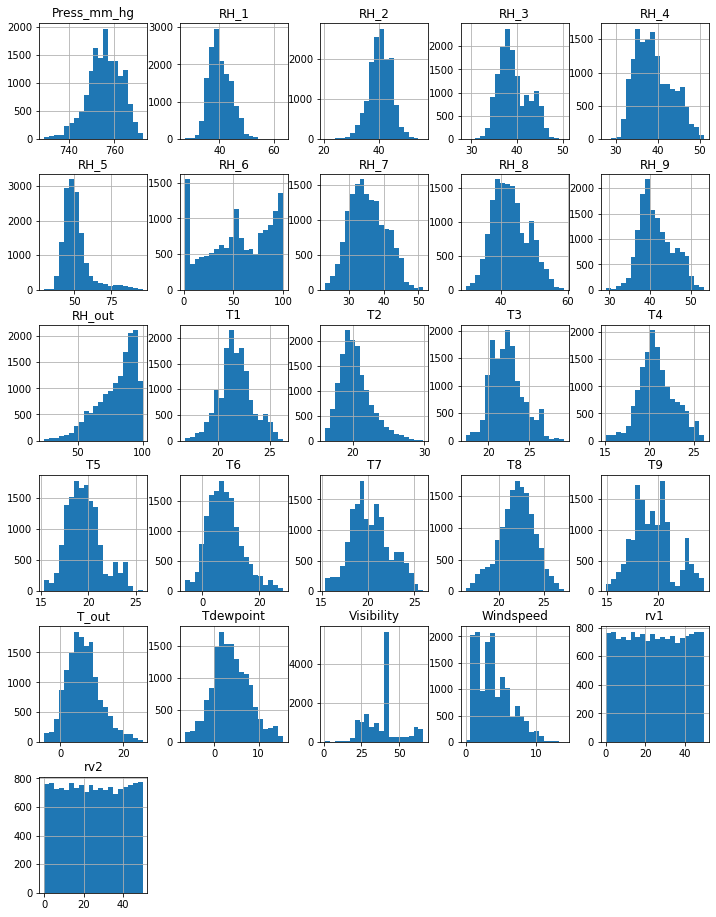

```python
# Histogram of all the features to understand the distribution
feature_vars.hist(bins = 20 , figsize= (12,16)) ;
```

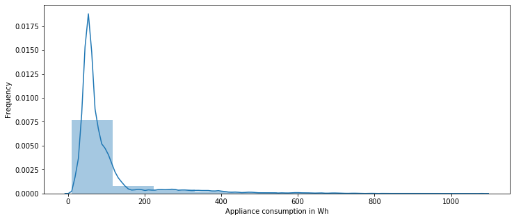

```python
# Distribution of values in Applainces column
f = plt.figure(figsize=(12,5))
plt.xlabel('Appliance consumption in Wh')
plt.ylabel('Frequency')
sns.distplot(target_vars , bins=10 ) ;
```

Observations